# Summer_courses_23_study

**Table of contents**

- Результаты летних курсов Летово Онлайн 2023
  - Imports
  - Task
  - Данные
  - Load
  - Заявки
  - Воронки
    - Внутренние курсы
    - Вдаль
    - Внешние курсы
    - Вывод по воронкам
  - Результаты
    - Вывод по результатам
  - Общий вывод

# Результаты летних курсов Летово Онлайн 2023

## Imports

```python
import pandas as pd
import numpy as np
import itertools

import matplotlib.pyplot as plt
import seaborn as sns
import matplotlib.ticker as ticker

LETOVO_PALETTE = ['#0D3174', '#FDC300', '#A40C30', '#00ADB9',
                     '#B2B2B2']

from plotly import graph_objects as go
import plotly.io as pio

pio.renderers.default = "notebook_connected"
pio.templates["letovo"] = go.layout.Template(
    layout_colorway=LETOVO_PALETTE
)
pio.templates.default = "letovo"

import warnings
warnings.filterwarnings("ignore")

plt.rcParams['figure.figsize'] = (16,10)
plt.rcParams['font.size'] = 22

sns.set_style('darkgrid')

plt.rcParams['figure.figsize'] = (16,9)
plt.rcParams['font.size'] = 22

YELLOW = '#FDC300'
BLUE = '#0D3174'
palette_dict = {1: YELLOW, 0: 'grey'}
```

## Task

На платформе Летово.Онлайн проводились **лентие курсы**. Хотим посмортеть

1. Сколько курсов (без олимпиад)
2. Заявки всего и с разбивкой по классам и курсам
3. Воронка Заявки/Приступили/Закончили
4. Вдаль воронка Заявки//Приступили/Финал
5. Результаты Эрудита
6. Воронка по внешним курсамНазначили/Приступили/Закончили
7. Сравнение среднего результата в курсах, включая внешних.

## Данные

**inner** - внутренние курсы платформы, заявки с 24.04.2023. **outer** - внешние курсы платформы, только избранные пользователи

Поля обеих таблиц:

- `lo_id` - Id ученик
- `full_name` - имя фамилия
- `email` - почта
- `grade` - класс
- `tick_status` - статус заявки
- `course_id` - ID курса
- `subject_name` - название предмета
- `lessons_completed` - кол-во уроков, в которых отправлено задание в курсе
- `course_lesson_cnt` - кол-во уроков в курсе, в которых можно отправить задание
- `student_score` - балл ученика за курс (только для тех, кто приступил к курсу, т.е. отправил хотя бы одно задание)
- `max_score` - максимальный балл за курс

Внимание, возможны дуликаты из-за предмета (у одного курса больше одного предмета)

## Load

Данные по обучению учеников на курсах. Пропуск в графе результат означает, что ученик не продвинулся дальше заявки на курс, не отправил ни одного урока с заданием.

```python
inner = pd.read_csv('courses_inner_summer.csv').sort_values(by='course_name')
inner.info()
```

```
<class 'pandas.core.frame.DataFrame'>
Int64Index: 6292 entries, 0 to 3055
Data columns (total 12 columns):
 #   Column             Non-Null Count  Dtype
---  ------             --------------  -----
 0   lo_id              6292 non-null   int64
 1   full_name          6292 non-null   object
 2   email              6292 non-null   object
 3   grade              6292 non-null   int64
 4   tick_status        6292 non-null   object
 5   course_id          6292 non-null   int64
 6   course_name        6292 non-null   object
 7   subject_name       6292 non-null   object
 8   lessons_completed  6292 non-null   int64
 9   course_lesson_cnt  6292 non-null   int64
 10  student_score      2394 non-null   float64
 11  max_score          6292 non-null   int64
dtypes: float64(1), int64(6), object(5)
memory usage: 639.0+ KB
```

```python
outer = pd.read_csv('courses_outer_summer.csv').sort_values(by='course_name')
outer.info()
```

```
<class 'pandas.core.frame.DataFrame'>
Int64Index: 3856 entries, 3099 to 1171
Data columns (total 12 columns):
 #   Column             Non-Null Count  Dtype
---  ------             --------------  -----
 0   lo_id              3856 non-null   int64
 1   full_name          3856 non-null   object
 2   email              3856 non-null   object
 3   grade              3856 non-null   int64
 4   tick_status        3856 non-null   object
 5   course_id          3856 non-null   int64
 6   course_name        3856 non-null   object
 7   subject_name       3856 non-null   object
 8   lessons_completed  3856 non-null   int64
 9   course_lesson_cnt  3856 non-null   int64
 10  student_score      1388 non-null   float64
 11  max_score          3856 non-null   int64
dtypes: float64(1), int64(6), object(5)
memory usage: 391.6+ KB
```

Нам нужны только конретные ученики во внешних курсах

```python
mask = ((outer['lo_id'].isin([668374, 668385, 668382, 628435, 668381, 668376, 668383, 668380, 668377, 608815])) & (outer['course_id'].isin([4, 34])))\
    | ((outer['lo_id'].isin([668359, 668546, 668361, 668366, 668216, 668217, 668219])) & (outer['course_id'].isin([36, 45])))\
    | ((outer['lo_id'].isin([669794, 669295, 669283, 669302, 669279, 669336, 69277, 669381, 669258, 669337, 669494, 669311, 669316, 669303, 669314, 669299, 669315, 669309, 501278, 669261, 669290, 669285, 669468, 669286, 669260, 669340, 669319, 669329, 669287, 669324, 669292, 669382])) & (outer['course_id'].isin([20, 23, 26, 66])))

outer = outer[mask].copy()
outer.shape[0]
```

```
102
```

```python
def add_columns(df: pd.DataFrame) -> pd.DataFrame:
    df['percent_score'] = df['student_score'] / df['max_score']

    df['course_started'] = 0
    df.loc[df['lessons_completed'] >= 1, 'course_started'] = 1

    df['course_100'] = 0
    df.loc[df['lessons_completed'] == df['course_lesson_cnt'], 'course_100'] = 1

    return df
inner = add_columns(inner)
outer = add_columns(outer)
```

```python
vdal = inner[inner['course_id'] == 37].copy()
inner = inner[inner['course_id'] != 37].copy()
```

```python
all_courses = pd.concat([inner, outer])
```

```python
course_cnt = outer['course_id'].nunique() + inner['course_id'].nunique()
print(f'Всего курсов (без олипиад): {course_cnt}')
```

```
Всего курсов (без олипиад): 21
```

## Заявки

```python
tick_cnt = outer['lo_id'].nunique() + inner['lo_id'].nunique()
print(f'Всего УП: {tick_cnt}')
```

```
Всего УП: 1775
```

```python
def unique_cnt_plot(df: pd.DataFrame, x: str, y: str,
                    title=None, xlabel=None, ylabel=None,
                    orient='v', order='count', palette = LETOVO_PALETTE):
  if orient == 'v':
    data = df.groupby(x)[y].nunique()
  if orient == 'h':
    data = df.groupby(y)[x].nunique()

  if order == 'count':
    ordnung = data.sort_values(ascending=False).index
  if order == 'index':
    ordnung = data.sort_index().index

  data = data.reset_index()
  ax = sns.barplot(data=data, x=x, y=y,
                   errorbar=('ci', 0), order=ordnung, palette=palette)
  ax.bar_label(ax.containers[0])
  ax.set(title=title, xlabel=xlabel, ylabel=ylabel)
  return ax
```

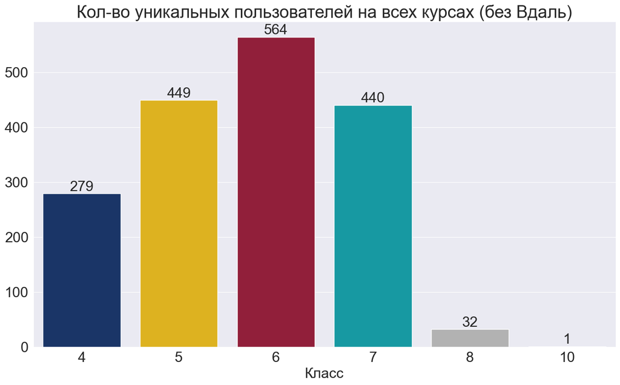

```python
unique_cnt_plot(all_courses, x='grade', y='lo_id',
                title='Кол-во уникальных пользователей на всех курсах (без Вдаль)', xlabel='Класс', order='index')
plt.show()
```

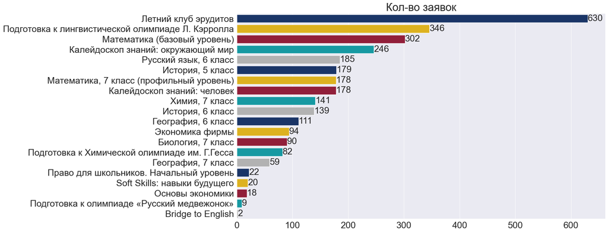

```python
unique_cnt_plot(all_courses, x='lo_id', y='course_name',
                title='Кол-во заявок', orient='h')
```

- Больше всего уникальных учеников среди 6 классников - 564
- Топ курсы по заявкам:
  - Эрудит - 630
  - Подготовка к Кэроллу - 346
  - Математика (базовый уровень) - 302

## Воронки

```python
def funnel(df, fig, name, step_names, course_fin_type='100_percent'):
    user_cnt = df['lo_id'].nunique()
    users_start = df[df['course_started'] == 1]['lo_id'].nunique()
    if course_fin_type == '100_percent':
        users_fin = df[df['course_100'] == 1]['lo_id'].nunique()
    if course_fin_type == 'finalist':
        users_fin = df[df['tick_status'] == 'accepted']['lo_id'].nunique()

    names = step_names
    values = [user_cnt, users_start, users_fin]

    fig.add_trace(go.Funnel(
        name = name,
        y = names,
        x = values,
        orientation='h',
        textinfo = "value+percent previous",
        textfont={'size':16}
    )
    )
```

Построим воронки по предметам

### Внутренние курсы

```python
def make_funnels_subject(df, step_names=['Заявка', 'Приступили', 'Закончили']):
    subjects = df['subject_name'].unique()

    for sub in subjects:
        fig = go.Figure()

        data = df[df['subject_name'] == sub]

        courses = data['course_name'].unique()

        for course in courses:
            funnel(data[data['course_name'] == course], fig, course, step_names)
        if len(courses) > 1:
            fig.update_layout(title=sub)
        else:
            fig.update_layout(title=sub + ", " + course)
        fig.show()

    return

make_funnels_subject(inner)
```

[interactive chart not shown]

### Вдаль

```python
fig = go.Figure()

funnel(vdal, fig, 'Вдаль', ['Заявки', 'Приступили', 'Финал'], course_fin_type='finalist')
fig.update_layout(title=vdal['course_name'].iloc[0])
fig.show()
```

[interactive chart not shown]

### Внешние курсы

```python
make_funnels_subject(outer, step_names = ['Назначены', 'Приступили', 'Завершили'])
```

[interactive chart not shown]

### Вывод по воронкам

- Конверсия в 50% и выше в приступившие может считаться высокой. Такую конверсию мы видим у некоторых курсов младше 7 класса:
  - Калейдоскоп знаний: окружающий мир - 54%
  - Калейдоскоп знаний: человек - 51%
  - География 6 класс - 51%.
- Что касается конверсии из приступивших в завершение, то тут наверное 30% будет границей:
  - География, 6 класс - 53%
  - Химия, 7 класс - 33%
  - История, 6 класс - 21%
- По внешним курсам шикарная конверсия в оба этапа воронки у курса Русский язык, 6 класс (89% и 38%).
- По Вдаль конверсии 47% и 40% соотвественно.

## Результаты

```python
def continuous_by_groups_plot(df: pd.DataFrame, x: str, y: str, outliers=False,
                              title: str=None, xlabel: str=None, ylabel: str=None, palette='Set2',
                              hue: str=None, hue_legend_labels: str=None, hue_legend_title: str=None):

  # выкидываем дубликаты, которые возможно есть из-за предмета
  df = df.drop_duplicates(subset=['lo_id', 'course_id'])
  group = df.groupby(y)[x]
  #порядок
  order = group.median().sort_values(ascending=False).index
  ax = sns.boxplot(data=df, x=x, y=y, showfliers=outliers, hue=hue,
                   palette=palette, order=order,
                   medianprops={'linewidth':'2', 'color':'white'})
  if title:
    ax.set_title(title)
  if xlabel:
    ax.set_xlabel(xlabel)
  if ylabel:
    ax.set_ylabel(ylabel)
  if hue_legend_labels:
    handles, labels = ax.get_legend_handles_labels()
    labels = hue_legend_labels
    ax.legend(handles, labels, title=hue_legend_title)
  ax.xaxis.set_major_formatter(ticker.PercentFormatter(1, decimals=0))

  display(group.describe().mul(100).round(2).sort_values(by='50%', ascending=False))
  return ax
```

| course_name | count | mean | std | min | 25% | 50% | 75% | max |
| --- | --- | --- | --- | --- | --- | --- | --- | --- |
| Калейдоскоп знаний: окружающий мир | 13200.0 | 60.52 | 35.27 | 0.00 | 29.41 | 76.47 | 94.12 | 100.00 |
| Летний клуб эрудитов | 13700.0 | 58.94 | 33.77 | 0.00 | 25.00 | 66.67 | 90.62 | 97.92 |
| Soft Skills: навыки будущего | 600.0 | 56.53 | 27.25 | 6.67 | 51.04 | 63.33 | 73.12 | 82.50 |
| Калейдоскоп знаний: человек | 9000.0 | 53.23 | 28.38 | 0.00 | 27.27 | 54.55 | 81.82 | 100.00 |
| География, 6 класс | 5700.0 | 46.08 | 28.98 | 5.03 | 18.87 | 48.43 | 70.44 | 94.34 |
| Подготовка к олимпиаде «Русский медвежонок» | 400.0 | 39.29 | 29.34 | 10.71 | 26.79 | 33.04 | 45.54 | 80.36 |
| Основы экономики | 200.0 | 26.31 | 7.12 | 21.27 | 23.79 | 26.31 | 28.82 | 31.34 |
| Право для школьников. Начальный уровень | 500.0 | 17.53 | 16.58 | 2.81 | 7.87 | 15.17 | 16.29 | 45.51 |
| Химия, 7 класс | 6400.0 | 26.27 | 24.35 | 0.78 | 6.20 | 15.12 | 44.19 | 89.92 |
| Подготовка к лингвистической олимпиаде Л. Кэрролла | 9200.0 | 23.80 | 27.09 | 0.00 | 0.00 | 15.12 | 43.60 | 87.21 |
| Математика (базовый уровень) | 13300.0 | 25.23 | 26.38 | 0.00 | 5.15 | 12.88 | 37.77 | 93.13 |
| География, 7 класс | 2100.0 | 32.43 | 33.22 | 2.37 | 5.33 | 11.83 | 66.27 | 92.31 |
| Экономика фирмы | 3800.0 | 31.38 | 30.92 | 0.00 | 5.77 | 11.54 | 61.54 | 82.05 |
| История, 5 класс | 7800.0 | 24.60 | 26.90 | 0.00 | 4.60 | 10.29 | 40.99 | 99.26 |
| История, 6 класс | 6100.0 | 18.13 | 21.49 | 0.00 | 5.24 | 6.67 | 26.19 | 89.52 |
| Математика, 7 класс (профильный уровень) | 5400.0 | 12.91 | 14.75 | 0.00 | 3.21 | 5.71 | 16.43 | 58.57 |
| Биология, 7 класс | 3900.0 | 14.84 | 19.09 | 0.00 | 0.00 | 4.75 | 25.21 | 64.69 |
| Русский язык, 6 класс | 9100.0 | 15.77 | 20.72 | 0.00 | 2.32 | 3.97 | 22.52 | 83.44 |
| Подготовка к Химической олимпиаде им. Г.Гесса | 900.0 | 11.37 | 24.26 | 0.00 | 0.00 | 0.00 | 0.00 | 69.00 |
| Bridge to English | 0.0 | NaN | NaN | NaN | NaN | NaN | NaN | NaN |

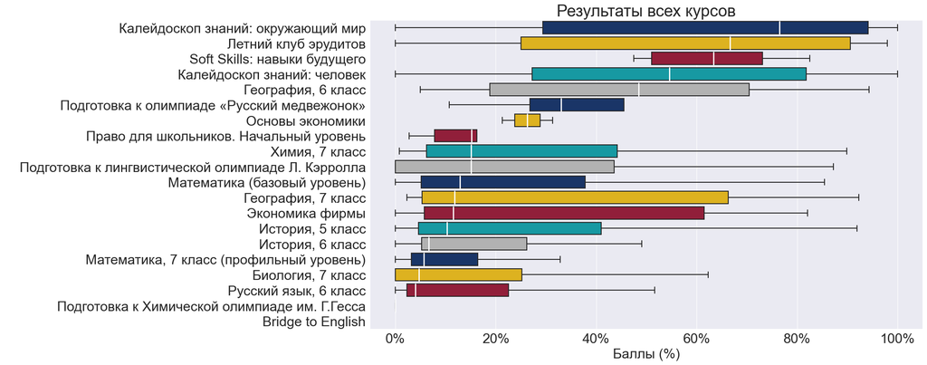

```python
continuous_by_groups_plot(
    all_courses, x='percent_score', y='course_name',
    title='Результаты всех курсов', xlabel='Баллы (%)', ylabel=' ',
    palette=LETOVO_PALETTE
)
plt.show()
```

## Общий вывод

**Заявки**

- Больше всего заявок на курсы от 6 классников - 564 уникальных пользователя
- Топ курсы по заявкам:
  - Эрудит - 630
  - Подготовка к Кэроллу - 346
  - Математика (базовый уровень) - 302

**Воронки**

- Конверсия в 50% и выше в приступившие может считаться высокой. Такую конверсию мы видим у некоторых курсов младше 7 класса:
  - Калейдоскоп знаний: окружающий мир - 54%
  - Калейдоскоп знаний: человек - 51%
  - География 6 класс - 51%.
- Что касается конверсии из приступивших в завершение, то тут наверное 30% будет границей:
  - География, 6 класс - 53%
  - Химия, 7 класс - 33%
  - История, 6 класс - 21%
- По внешним курсам шикарная конверсия в оба этапа воронки у курса Русский язык, 6 класс (89% и 38%).
- По Вдаль конверсии 47% и 40% соотвественно.

**Результаты**